# 3.0.3. Modelos RANDOM FOREST

Realizado por:

*Sergio Ranz Casado*  
*Marcos Medina Cogolludo*

## **3.0.3. Modelo RANDOM FOREST**

Un [`random forest`](https://towardsdatascience.com/understanding-random-forest-58381e0602d2) consta de una gran cantidad de arboles de decisión individuales que operan en conjunto. Cada árbol individual en el bosque aleatorio escupe una predicción de clase y la clase con más votos se convierte en la predicción de nuestro modelo.

## **METODOS DE CLASIFICACIÓN**

Como ya hemos comentado en notebooks anteriores. El principal problema que nos encontramos en este dataset es el desbalanceo de datos. La gran desproporcionalidad que existe entre los accidentes de trafico mortales de los que no son mortales es de 2% a 98%. Si bien, es cierto que hemos actuado frente a este desbalanceo mediante una `técnica de muestreo aleatorio`en el notebook [2.0.3.Preprocesing.](http://localhost:8888/notebooks/Desktop/CUNEF/Practica%20Machine%20Learning/project_template/notebooks/2.0.3.%20Preprocesing.%20SPLIT%2C%20NA%2C%20OUTLIER.%20.ipynb)

Sin embargo, nos seguimos encontrado con este problema en la muestra de test seleccionada. Esto afectará a nuestras métricas, en nuestro caso, no representarán la precisión ni el recall adecuado del modelo.

Sabiendo el problema al que nos enfrentamos y teniendo como objetivo la predicción de la mortalidad en un accidente de tráfico. (Problema de clasificación), enumeramos a continuación las métricas que vamos a utilizar:

- `Precisión:` Se define como la división de los verdaderos positivos (TP) de entre todos los positivos predichos (TP + FP).En nuestro caso en particular, será este dato el que este desequilibrado, ya que hay una desproporcionalidad de la muestra de muertes y no muertes.

$$\frac{\textrm{TP}}{\textrm{TP+FP}}$$

- `Recall:` Se define como todos los ejemplos predichos que pertenecen a una clase (TP) de entre todos los positivos predichos (TP + FN).

$$\frac{\textrm{TP}}{\textrm{TP+FN}}$$

- [`Accuracy`](https://machinelearningmastery.com/failure-of-accuracy-for-imbalanced-class-distributions/): Es una metrica que resume el rendimiento de un modelo de clasificación con el número de predicciones correctas dividido por el número total de predicciones. Debido a que la predicción no es una métrica fiable, esta métrica tampoco lo será.

$$\frac{\textrm{TP+TN}}{\textrm{TP+TN+FP+FN}}$$

- [`Matriz de confusión:`](https://medium.com/analytics-vidhya/accuracy-on-imbalanced-datasets-and-why-you-need-confusion-matrix-937613bf89bf) La métrica mas simple y al mismo tiempo la más efectiva para mirar el desempeño de los modelos en casos de dataset imbalanceados. Nos muestra la relacción que existe entre positivos acertados (TP), positivos fallados (FN), negativos acertados(TN), y negativos fallados (FP).
- [`F1-Score:`](https://www.iartificial.net/precision-recall-f1-accuracy-en-clasificacion/) La F-Score combina las dos métricas de precisión y recall dentro de un mismo valor, añadiendo un parámetro `Beta`, que aplica un peso mayor a la precisión (Beta < 1) o un peso mayor al recall (Beta > 1). En nuestro caso, aplicaremos una F-1, ya que el peso lo aplicaremos en el modelo.

$$2 \times\frac{\textrm{Precision} \times \textrm{Recall}}{\textrm{Precision} + \textrm{Recall}}$$

- [`La curva ROC:`](https://machinelearningmastery.com/roc-curves-and-precision-recall-curves-for-imbalanced-classification/) Resume el rendimiento del modelo en la clase binaria positiva. Es una herramienta de diagnóstico popular para clasificadores en problemas de predicción binaria balanceados y desequilibrados por igual porque no está sesgada hacia la clase mayoritaria o minoritaria.
- [`Precision-Recall AUC:`](https://www.davidsbatista.net/blog/2018/08/19/NLP_Metrics/) Representa la precisión y el recall para diferentes umbrales de probabilidad. Es una tecnica muy efectiva para dataset desequilibrados debido a su enfoque en la clase minoritaria, es decir, en la mortalidad.
- [`Cumulative Gain Curve`](https://towardsdatascience.com/meaningful-metrics-cumulative-gains-and-lyft-charts-7aac02fc5c14#:~:text=The%20cumulative%20gains%20curve%20is,target%20according%20to%20the%20model.) Evalua el rendimiento del modelo comparando los resultado con la selección aleatoria.
- [`Lift Curve`](https://towardsdatascience.com/meaningful-metrics-cumulative-gains-and-lyft-charts-7aac02fc5c14#:~:text=The%20cumulative%20gains%20curve%20is,target%20according%20to%20the%20model.) Mide la cantidad de ganancias que tiene nuestro modelo aplicandolo con respecto a la selección aleatorio. Nos indica cuanto vale la pena implementar ese modelo.

#### Importo Librerias

```python
import warnings
warnings.filterwarnings('ignore')
```

```python
import pandas as pd
import pyarrow.csv as pv
import pyarrow.parquet as pq
import seaborn as sns
import numpy as np
from matplotlib import pyplot as plt
from matplotlib import pyplot
from sklearn import preprocessing
import pandas as pd
import pyarrow.csv as pv
import pyarrow.parquet as pq
import seaborn as sns
from sklearn.model_selection import train_test_split
from sklearn.ensemble import RandomForestClassifier
from sklearn import metrics
from sklearn.metrics import classification_report, confusion_matrix, roc_curve, auc, \
                            silhouette_score, recall_score, precision_score, make_scorer, \
                            roc_auc_score, f1_score, precision_recall_curve
from sklearn.metrics import accuracy_score, roc_auc_score, \
                            classification_report, confusion_matrix
from sklearn.metrics import plot_confusion_matrix
from sklearn import tree
from sklearn.model_selection import GridSearchCV, RandomizedSearchCV
from sklearn.metrics import fbeta_score
from sklearn.model_selection import cross_val_score
from sklearn.model_selection import RepeatedStratifiedKFold
from sklearn.model_selection import GridSearchCV
import time
import pickle
import scikitplot as skplt
```

#### Importamos funciones:

```python
def classify_metrics(modelo, x_test, y_test, predict):

    '''Imprimimos el reporte de clasificación:  '''

    print("Classification Report")
    print(classification_report(y_test, predict))

    '''Imprimimos el Accuracy: '''
    print("Accuracy:", metrics.accuracy_score(y_test, predict))

    '''Imprimimos el F1-score'''
    print("F1-Score:", metrics.f1_score(y_test, predict))

    print("---")

    '''Matriz de confusión: '''
    titles_options = [("Confusion matrix, without normalization", None),
                  ("Normalized confusion matrix", 'true')]
    for title, normalize in titles_options:
        disp = plot_confusion_matrix(modelo, x_test, y_test,
                                     display_labels=["mortal", "no mortal"],
                                     cmap=plt.cm.Blues,
                                     normalize=normalize)
        disp.ax_.set_title(title)

        print(title)
        print(disp.confusion_matrix)

    plt.show()

    yhat = modelo.predict_proba(x_test)
    pos_pred = yhat[:,1]

    # calculate roc curves
    fpr, tpr, thresholds = roc_curve(y_test, pos_pred)
    # plot the roc curve for the model
    plt.plot([0,1], [0,1], linestyle='--', label='No Skill')
    plt.plot(fpr, tpr, marker='.', label='Random Forest')
    # axis labels
    plt.xlabel('False Positive Rate')
    plt.ylabel('True Positive Rate')
    plt.legend()
    # show the plot
    plt.show()


    # calculate the g-mean for each threshold
    gmeans = np.sqrt(tpr * (1-fpr))

    # locate the index of the largest g-mean
    ix = np.argmax(gmeans)
    print('Best Threshold=%f, G-Mean=%.3f' % (thresholds[ix], gmeans[ix]))

    '''Dibujando la curva ROC: '''
    print("CURVA ROC con THRESHOLD:")
    # plot the roc curve for the model
    plt.plot([0,1], [0,1], linestyle='--', label='No Skill')
    plt.plot(fpr, tpr, marker='.', label='Modelo')
    plt.scatter(fpr[ix], tpr[ix], s=100, marker='o', color='black', label='Best')
    # axis labels
    plt.xlabel('False Positive Rate')
    plt.ylabel('True Positive Rate')
    plt.legend()
    # show the plot
    plt.show()

    '''Calculando el area AUC: '''
    print("AREA AUC: ")
    # calculate roc auc
    roc_auc = roc_auc_score(y_test, pos_pred)
    print('ROC AUC %.3f' % roc_auc)

    '''Calculamos la curva pr: '''
    # calculate pr-curve
    precision, recall, thresholds = precision_recall_curve(y_test, pos_pred)
    print("PRECISSION/RECALL CURVE: ")
    # plot the roc curve for the model
    no_skill = len(y_test[y_test==1]) / len(y_test)
    plt.plot([0,1], [no_skill,no_skill], linestyle='--', label='No Skill')
    plt.plot(recall, precision, marker='.', label='Random Forest')
    # axis labels
    plt.xlabel('Recall')
    plt.ylabel('Precision')
    plt.legend()
    # show the plot
    plt.show()

    '''Cumulative Gain Curve: '''
    skplt.metrics.plot_cumulative_gain(y_test, yhat)
    plt.show()

    '''Lift Curve:'''
    skplt.metrics.plot_lift_curve(y_test, yhat)
    plt.show()
```

#### Importamos el train y test seleccionado:

```python
train = pd.read_parquet('../data/trainselect1.parquet')
test = pd.read_parquet('../data/testselect1.parquet')
```

Divido entre 'xtrain' e 'ytrain'

```python
x_train = train.drop('c_sev',axis=1)
x_test = test.drop('c_sev',axis=1)
y_train = train['c_sev']
y_test = test['c_sev']
```

#### RANDOM FOREST :

Le introducimos el parametro class_weight, para evitar la desporporcionalidad del dataset, en este sentido, le aplicamos a 1 un peso elevado para ver como reacciona el modelo. Ya que, con el 40,60 que hemos empleado en la [`regresión lineal`](http://localhost:8888/notebooks/Desktop/CUNEF/Practica%20Machine%20Learning/project_template/notebooks/3.0.2.%20Modelos.%20Linear%20Regression.%20.ipynb) no nos sirve. Parece que el modelo no aprende de los accidentes.

```python
%%time
rf = RandomForestClassifier(class_weight={0:1,1:1000})
start = time.time()
model3 = rf.fit(x_train, y_train)
end= time.time()
y_pred_rf = model3.predict(x_test)
print(y_pred_rf)
print("Tiempo de ejecución fit: ", end-start)
```

```
[1 1 1 ... 1 1 0]
Tiempo de ejecución fit:  7.12799859046936
Wall time: 19.3 s
```

#### Metricas:

```
Classification Report
              precision    recall  f1-score   support

           0       0.04      0.61      0.08      8960
           1       0.99      0.74      0.84    453620

    accuracy                           0.73    462580
   macro avg       0.52      0.67      0.46    462580
weighted avg       0.97      0.73      0.83    462580

Accuracy: 0.7328224307146872
F1-Score: 0.8436758085875788
---
Confusion matrix, without normalization
[[  5481   3479]
 [120112 333508]]
Normalized confusion matrix
[[0.61171875 0.38828125]
 [0.2647855  0.7352145 ]]
```

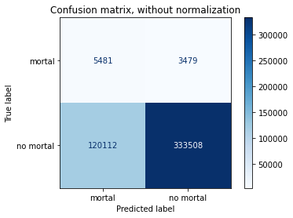

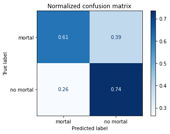

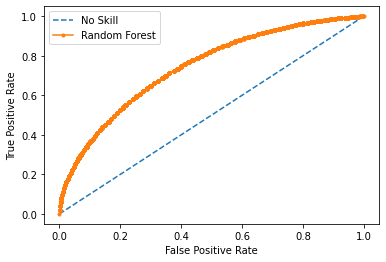

```
Best Threshold=0.559998, G-Mean=0.675
CURVA ROC con THRESHOLD:
```

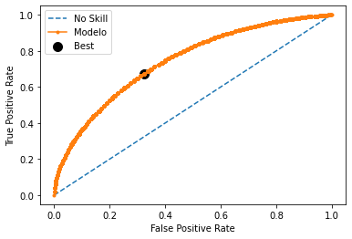

```
AREA AUC:
ROC AUC 0.744
PRECISSION/RECALL CURVE:
```

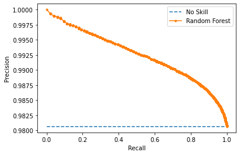

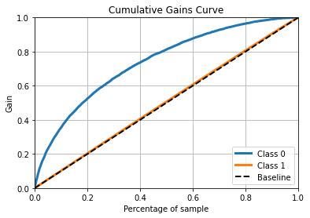

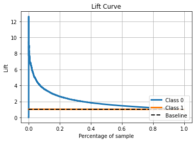

```python
classify_metrics(model3, x_test, y_test, y_pred_rf)
```

#### AJUSTAMOS EL MODELO CON EL THRESHOLD OBTENIDO

```python
'''Definimos los thresholds, el gmeans, el fpr y el tpr: '''
yhat = model3.predict_proba(x_test)
pos_pred = yhat[:,1]
fpr, tpr, thresholds = roc_curve(y_test, pos_pred)
gmeans = np.sqrt(tpr * (1-fpr))
ix = np.argmax(gmeans)
```

```python
'''Realizamos la predicción aplicando el threshold: '''
y_pred_final = (pos_pred >= thresholds[ix]).astype(int)
y_pred_final
```

```
array([1, 0, 0, ..., 1, 1, 0])
```

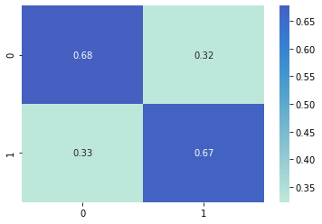

```python
x = metrics.confusion_matrix(y_test,y_pred_final, normalize='true')
sns.heatmap(x, annot=True, center=1)
```

#### Comentarios:

La curva roc arroja un area un pelín menor que la regresión lineal.

#### Queremos determinar la importancia de las variables sobre la variable objetivo:

Parece que ha cambiado el peso de la variable con respecto al resto de los modelos. En el random forest tiene mas peso las horas, las semanas y los meses que la configuración del accidente o la configuración del asfalto, que pasa a tener una importancia media.

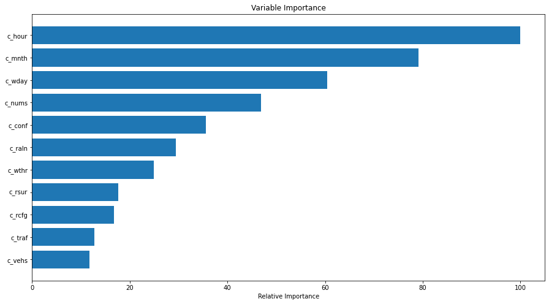

```python
feature_importance = model3.feature_importances_
feature_importance = 100.0 * (feature_importance / feature_importance.max())
sorted_idx = np.argsort(feature_importance)
pos = np.arange(sorted_idx.shape[0]) + .5
# plt.subplot(1, 2, 2)
plt.figure(figsize=(15, 8))
plt.barh(pos, feature_importance[sorted_idx], align='center')
plt.yticks(pos, x_train.keys()[sorted_idx])
plt.xlabel('Relative Importance')
plt.title('Variable Importance')
plt.show()
```

#### RANDOM FOREST CON VALIDACIÓN CRUZADA.

La [`validación cruzada o cross-validation`](https://es.wikipedia.org/wiki/Validaci%C3%B3n_cruzada) es una técnica utilizada para evaluar los resultados de un análisis estadístico y garantizar que son independientes de la partición entre datos de entrenamiento y prueba. Consiste en repetir y calcular la media aritmética obtenida de las medidas de evaluación sobre diferentes particiones.

En este dataset nos volvemos a topar con el problema de desbalanceo del dataset sobre todo en la parte del test. Para ello, el cross validation tiene que adaptarse a esta desproporción. Utilizaremos el 'RepeatedStratifiedKFold' que estratifica la muestra de train manteniendo la proporción de muertes y no muertes.

Por otro lado, combinaremos el cross validation con el GridSearch, para encontrar los mejores parametros que se adapten a nuestro modelo. En este sentido, comentamos los parametros sobre los que vamos a buscar su mejor optimización:

Asimismo, utilizaremos el [`gridsearch`](https://scikit-learn.org/stable/modules/generated/sklearn.model_selection.GridSearchCV.html) para encontrar los mejores parametros, esta función tambien tiene parametros que son dignos de mención:

- `verbose:` Pondremos =1 para que nos de el tiempo de ejecución del codigo.
- `n_jobs:` Pondremos =-1 para que la maquina utilice todos los procesadores de la cpu.

```python
parameters = {
    'n_estimators': np.arange(150,170,10),
    'criterion': ('gini', 'entropy'),
    'max_depth': np.arange(4,8,1),
    'class_weight': ('balanced', 'balanced_subsample', None)
}

rfc = RandomForestClassifier(class_weight={0:1,1:1000})

'''Asignamos la validación cruzada: '''
cv = RepeatedStratifiedKFold(n_splits=10, n_repeats=3, random_state=12345)

'''Asignamos el GridSearch: '''
start=time.time()
gs = GridSearchCV(rfc, parameters, verbose=1, n_jobs=-1, cv=cv, scoring='roc_auc')
model3cv = gs.fit(x_train, y_train)
end=time.time()
y_pred_rfc_cv = model3cv.predict(x_test)

'''imprimimos los parametros: '''
print(model3cv.best_params_)
print(model3cv.best_score_)
print("Tiempo de ejecución: ", end-start)
```

```
Fitting 30 folds for each of 48 candidates, totalling 1440 fits
{'class_weight': None, 'criterion': 'gini', 'max_depth': 7, 'n_estimators': 160}
0.7702116512837774
Tiempo de ejecución:  1009.7311637401581
```

#### Guardamos el modelo con [`Pickle`](https://machinelearningmastery.com/save-load-machine-learning-models-python-scikit-learn/)

```python
filename = '../models/model3cv.sav'
pickle.dump(model3cv, open(filename, 'wb'))
```

#### Load Pickle.

```python
filename = '../models/model3cv.sav'
model3cv = pickle.load(open(filename, 'rb'))
y_pred_rfc_cv = model3cv.predict(x_test)
print(y_pred_rfc_cv)
```

```
[1 1 0 ... 1 1 1]
```

#### Metricas

```
Classification Report
              precision    recall  f1-score   support

           0       0.06      0.52      0.10      8960
           1       0.99      0.83      0.90    453620

    accuracy                           0.82    462580
   macro avg       0.52      0.67      0.50    462580
weighted avg       0.97      0.82      0.88    462580

Accuracy: 0.8207639759609149
F1-Score: 0.9004525267175665
---
Confusion matrix, without normalization
[[  4685   4275]
 [ 78636 374984]]
Normalized confusion matrix
[[0.52287946 0.47712054]
 [0.17335214 0.82664786]]
```

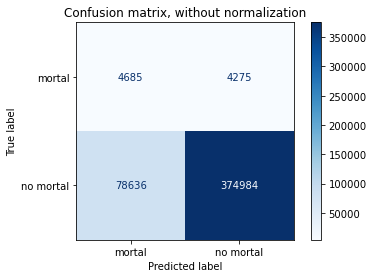

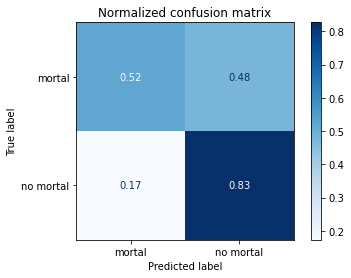

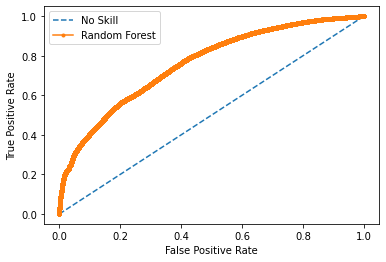

```
Best Threshold=0.572506, G-Mean=0.680
CURVA ROC con THRESHOLD:
```

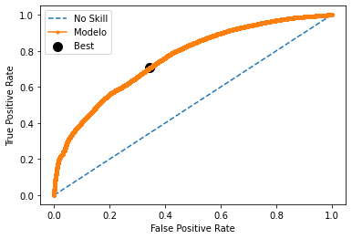

```
AREA AUC:
ROC AUC 0.761
PRECISSION/RECALL CURVE:
```

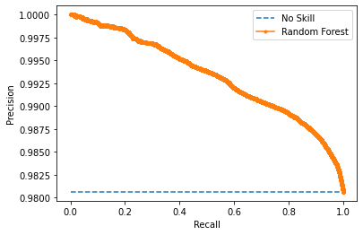

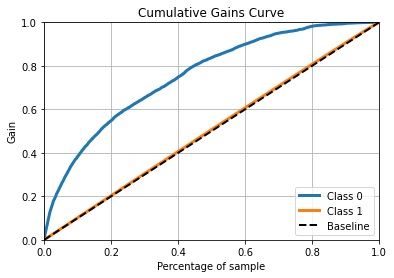

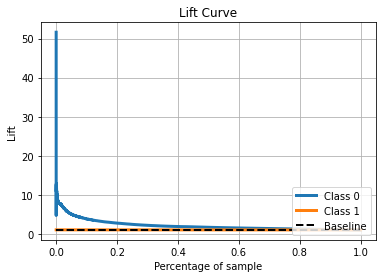

```python
classify_metrics(model3cv, x_test, y_test, y_pred_rfc_cv)
```

#### AJUSTAMOS EL MODELO CON EL THRESHOLD OBTENIDO:

```python
'''Definimos los thresholds, el gmeans, el fpr y el tpr: '''
yhat = model3cv.predict_proba(x_test)
pos_pred = yhat[:,1]
fpr, tpr, thresholds = roc_curve(y_test, pos_pred)
gmeans = np.sqrt(tpr * (1-fpr))
ix = np.argmax(gmeans)
```

```python
yhat = model3cv.predict_proba(x_test)
pos_pred = yhat[:,1]
```

```python
y_pred_final_2 = (pos_pred >= thresholds[ix]).astype(int)
y_pred_final_2
```

```
array([1, 1, 0, ..., 1, 1, 1])
```

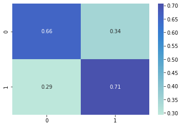

```python
x = metrics.confusion_matrix(y_test,y_pred_final_2, normalize='true')
sns.heatmap(x, annot=True, center=1)
```

#### Comentarios:

Despues de realizar un GridSearch junto con el cross validation no hemos obtenido mejores resultados del modelo, que sigue sin identificar bien los casos de accidentes con mortalidad.

Hemos realizando la predicción aplicando el mejor threshold que, en el modelo sin optimizar nos ha dado un resultado razonable, sin embargo, en el modelo parametrizado no ha sido suficiente.

**Descartamos este modelo debido a sus predicciones y al tiempo que emplea en ejecutarse.**

#### Enlaces de interés:

[`Random forest for imbalanced data`](https://machinelearningmastery.com/bagging-and-random-forest-for-imbalanced-classification/)

[`Random Forest DataCamp`](https://www.datacamp.com/community/tutorials/random-forests-classifier-python)

[`Random Forest Scikit-Learn`](https://scikit-learn.org/stable/modules/generated/sklearn.ensemble.RandomForestClassifier.html)

[`Random Forest para Dataset desbalanceados`](https://machinelearningmastery.com/bagging-and-random-forest-for-imbalanced-classification/)